# NR_5021_project

10/3/2018

# Better Know an R Package

## R/Cowplot

Cowplot is a package developed to work in tandem with R/ggplot2. From the cowplot cran page, “The cowplot package is a simple add-on to ggplot2. It is meant to provide a publication-ready theme for ggplot2, one that requires a minimum amount of fiddling with sizes of axis labels, plot backgrounds, etc.”

```r
#install.packages("cowplot")
library(tidyverse); library(ggplot2)
```

### Load in the data

We are using a data set that is within ggplot2 as well as a dataset collected from class responses. The data set from ggplot2 is called “msleep” and records average sleep data, taxonomy, diet information, and brain and body weight for 83 mammal species. The class data includes reported hours of sleep and body weight in kilograms.

```r
animal <- msleep

weight <- c(74,63,112,70,55,50,75,59,93,88.64,54.4,84,68.18,130,100,79.54,77,52,79.5,68.2,57.72)

sleep<- c(6,6,6,6.5,6.5,7,7,7,7,7,7,7,7,7,7.25,7.5,7.5,8,8,8,9)

class_sleep <- data.frame(weight,sleep)

class_sleep_summary<- summarize(class_sleep,
                                mean.sleep = mean(sleep),
                                mean.weight = mean(weight))
class_sleep_summary
```

```
##   mean.sleep mean.weight
## 1   7.107143    75.72286
```

```r
## Now we will add our class data to the msleep dataset.
name<- "Class"
class.sleep<- cbind(class_sleep_summary,name)

class.sleep<- data.frame(class.sleep$name,class.sleep$mean.sleep,class.sleep$mean.weight)
names(class.sleep) <- c("msleep.name", "msleep.sleep_total", "msleep.bodywt")
new.msleep <- data.frame(msleep$name, msleep$sleep_total, msleep$bodywt)

new.msleep.class<- rbind(new.msleep, class.sleep)
```

## ggplot2

First we will make several different plots using solely ggplot2 functions

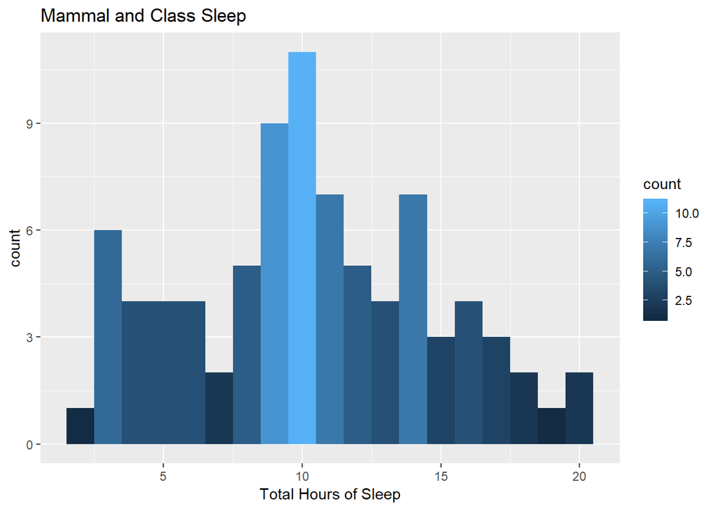

```r
msleep.hist <- ggplot(new.msleep.class, aes(x=msleep.sleep_total)) + geom_histogram(binwidth=1, aes(fill=..count..)) + labs(title="Mammal and Class Sleep") + xlab("Total Hours of Sleep")
msleep.hist #Creates a histogram for hours of sleep for both the msleep and the class data
```

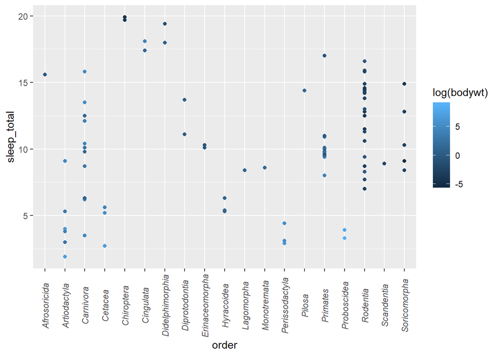

```r
p <- ggplot(animal, aes(x = order, y = sleep_total)) + theme(axis.text.x = element_text(face = "italic", angle = 90, vjust = 0.5)) + geom_point() + aes(colour = log(bodywt))
p
```

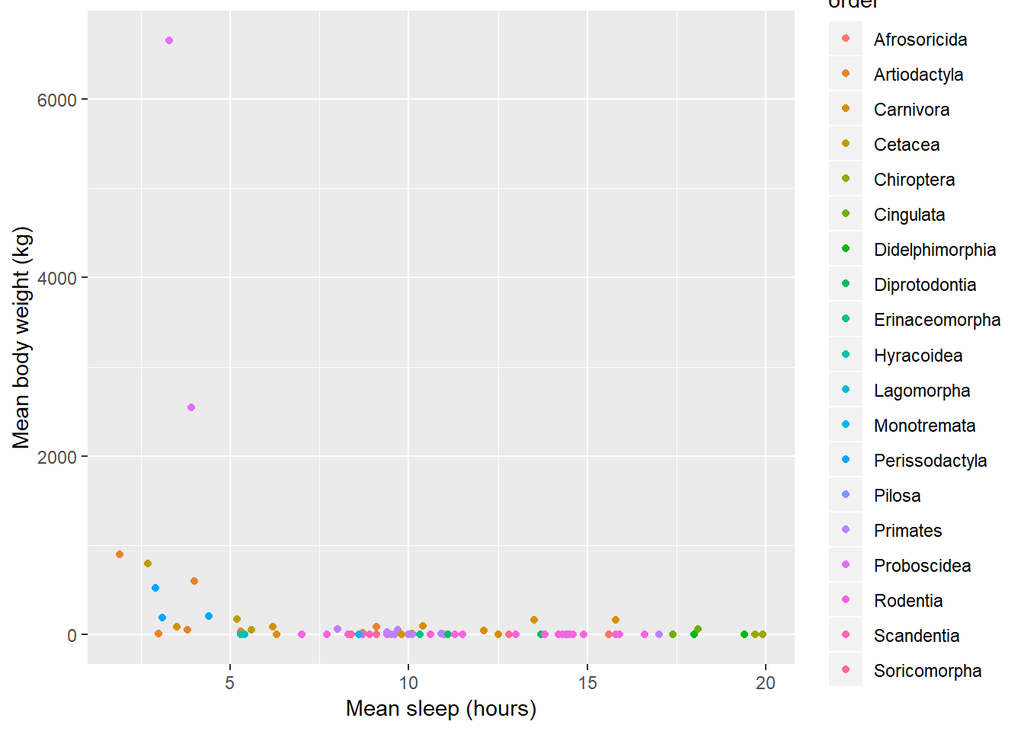

```r
sleep.plot<-ggplot(msleep, aes(x=msleep$sleep_total, y=msleep$bodywt,colour=order)) + geom_point() + labs(x="Mean sleep (hours)", y= "Mean body weight (kg)")
sleep.plot
```

## The cowplot difference Notice that in cowplot, the default gray background and grid lines present in ggplot2 are missing. A similar design can also be achieved in ggplot using “+ theme_classic”

One unique feature of cowplot is the capacity to add images to your plots. For instance, we can add an image of an elephant to the background. To include this feature, we must first download the package “magick.” You can change the size of the background image using “scale=”. Before we can use cowplot, we still have to have a basic understanding of ggplot

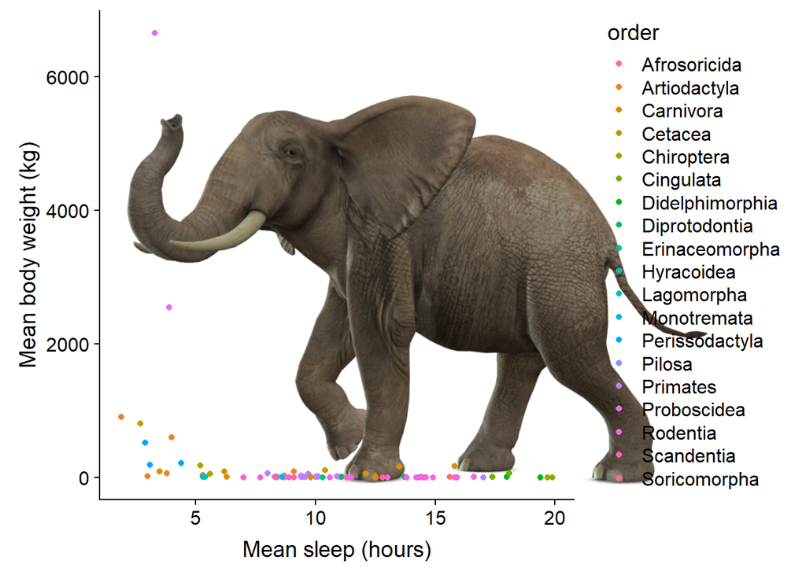

```r
library(cowplot)
#install.packages("magick")
library(magick)
elephant <- image_read('https://github.com/Hiagha/NR5021/blob/master/elephant.png?raw=true')
elephant.background <- ggdraw() + draw_image(elephant,scale=0.8) + draw_plot(sleep.plot)
elephant.background
```

## Labeling You can also use cowplot to add labels to plots. The x and y axis denote where you want the label to appear on the plot. One limitation of cowplot is that the code can get long as more features, like labels, are added to the plot

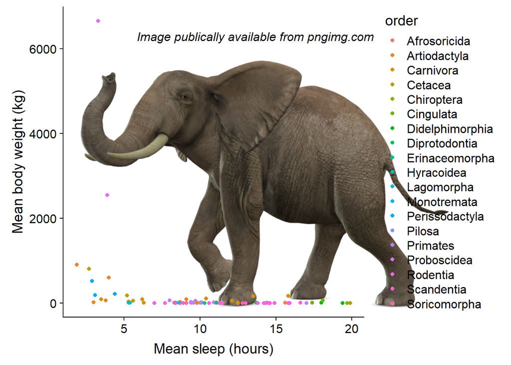

```r
elephant.background+draw_label("Image publically available from pngimg.com", x=0.5, y=0.9, size=12, fontface = "italic")
```

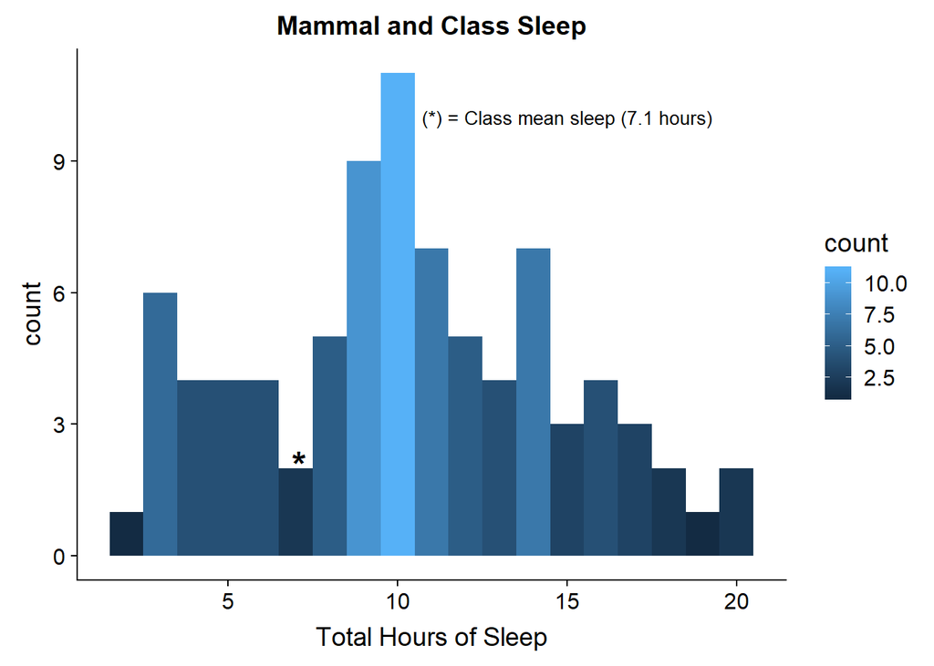

```r
##Let's add a label to our histogram to denote the location of the mean class sleep total with respect to all mammal sleep totals.

sleep.hist<- msleep.hist + draw_label("(*) = Class mean sleep (7.1 hours)", x=15, y=10, size=10,fontface="plain") + draw_label("*", x=7.1,y=2.1,size=20,fontface="bold")
sleep.hist
```

## Comparing plots

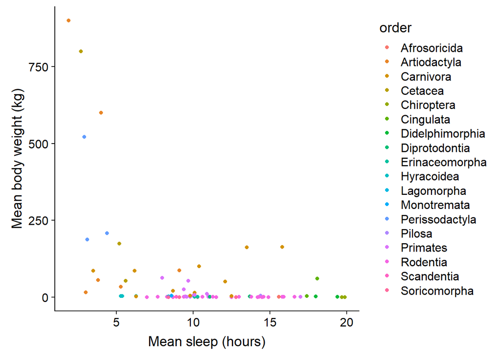

```r
no.elephant.animal <- animal[-c(21,36),] #This code gets rid of rows 21 and 36 in the animal data set, corresponding to the two elephants (African and Asian)
#View(no.elephant.animal) #This code lets us view the new data table to confirm that the rows with the elephant information are eliminated
no.elephant.sleep.plot <- ggplot(no.elephant.animal, aes(x=no.elephant.animal$sleep_total, y=no.elephant.animal$bodywt,colour=order)) + geom_point() + labs(x="Mean sleep (hours)", y= "Mean body weight (kg)")
no.elephant.sleep.plot
```

## Combining plots Another advantage of cowplot is that it can combine plots into a grid or other arrangements. We can specify the size of each plot and where we want it to appear. For example, we can insert the smaller mammal mean sleep vs. mean body mass plot by a larger version of the same plot that excludes the elephant data points. To do this, we will again use the ggdraw() and draw_plot functions of cowplot. We will also remove the legend for the smaller plot and place the legend on the left for the larger plot to make it easier to view both graphs. One difficulty with combining plots into layouts besides grid arrangements is it can be challenging to anticipate the coordinates where you want the plot to appear. Achieving the layout that you want may take some trial and error in the code for the coordinates. Here, the first two numbers denote where you want the plot on the x and y axis. The second set of coordinates show the scales of the x and y axis, respectively

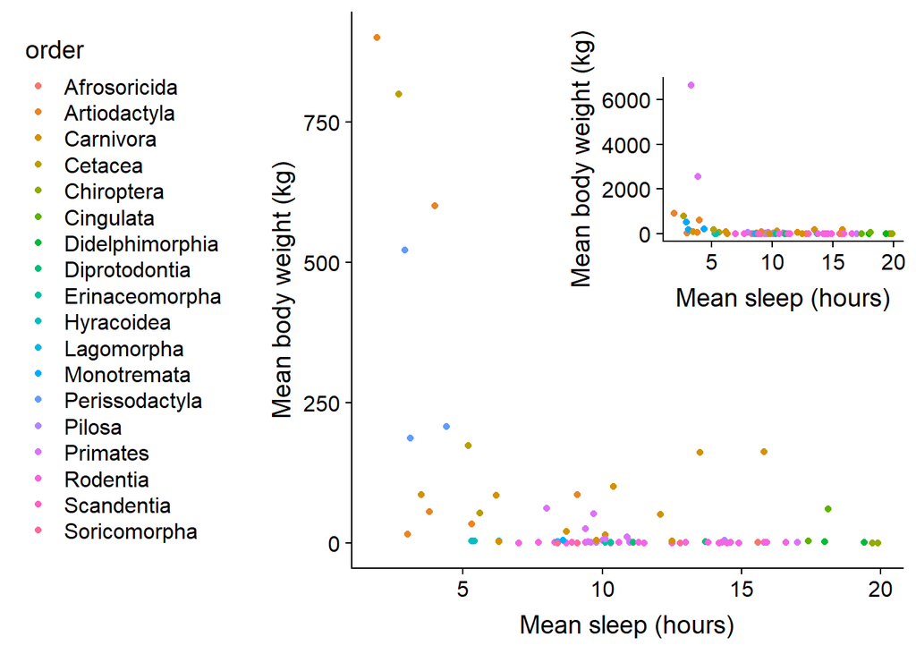

```r
ggdraw() + draw_plot(no.elephant.sleep.plot + theme(legend.position = "left")) + draw_plot(sleep.plot + theme(legend.position = "none"), 0.6,0.5,0.4,0.4)
```

## Presentation ready plots

Cowplot also allows for multiple plots to put plotted gridwise with labels and then saved as a single object. This is very useful when getting plots ready for presentation or publication. Cowplot improves the functionality of *ggsave( )* and makes it possible to save these combined plots as a single object.

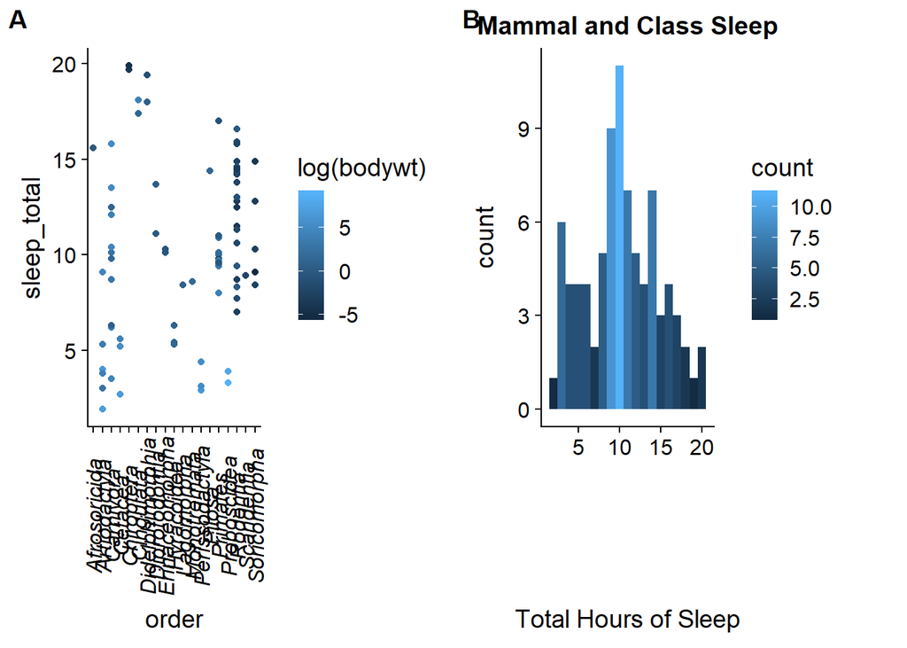

```r
side.by.side <- plot_grid(p, msleep.hist, labels = c("A", "B"), align = "hv", axis = "tb")
side.by.side
```

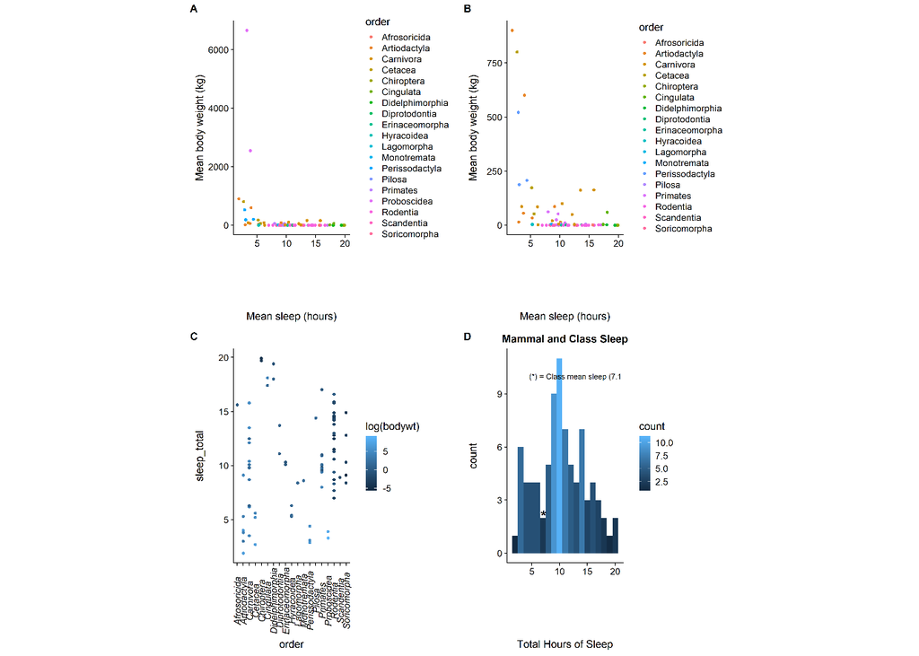

```r
# We can also save our combined plots using ggsave(), setting appropriate height/width and DPI for whatever project you are working on.

four.plot <- plot_grid(sleep.plot, no.elephant.sleep.plot, p, sleep.hist, labels = c("A", "B", "C", "D"), align = "hv", axis = "tblr")
ggsave("fourplot.png", four.plot, width = 10, height = 12)

plots <- image_read("fourplot.png")
ggdraw() + draw_image(plots)
```

## Contributions

James created the class survey, combined the class data with the msleep dataset and created the histograms for the combined datasets. Hannah created the plots of sleep vs bodyweight associated with the msleep dataset and highlighted the cowplot properties of adding photos to a figure. She also highlighted the limitations and difficulties of cowplot throughout the Rmarkdown document. Husain provided the cowplot expertise and highlighted the cowplot functions of adding a subset image within a figure, aligning various plots and ensuring the overall figure is publication-ready. Clare was responsible for the Flipgrid video highlighting the cowplot package and its benefits and limitations.